# Risk Factor Analysis

## Outcome Variable

**Outcome Variable:** ever_swasted

## Predictor Variables

**Intervention Variable:** mage

**Adjustment Set:**

- arm
- meducyrs
- feducyrs
- W_mhtcm
- W_mwtkg
- W_mbmi
- single
- delta_meducyrs
- delta_feducyrs
- delta_W_mhtcm
- delta_W_mwtkg
- delta_W_mbmi
- delta_single

## Stratifying Variables

The analysis was stratified on these variable(s):

- agecat
- studyid
- country

## Data Summary

| agecat | studyid | country | mage | ever_swasted | n_cell | n |
| --- | --- | --- | --- | --- | --- | --- |
| 0-24 months | CMC-V-BCS-2002 | INDIA | [20-30) | 0 | 222 | 373 |
| 0-24 months | CMC-V-BCS-2002 | INDIA | [20-30) | 1 | 74 | 373 |
| 0-24 months | CMC-V-BCS-2002 | INDIA | <20 | 0 | 27 | 373 |
| 0-24 months | CMC-V-BCS-2002 | INDIA | <20 | 1 | 7 | 373 |
| 0-24 months | CMC-V-BCS-2002 | INDIA | >=30 | 0 | 32 | 373 |
| 0-24 months | CMC-V-BCS-2002 | INDIA | >=30 | 1 | 11 | 373 |
| 0-24 months | COHORTS | GUATEMALA | [20-30) | 0 | 608 | 1341 |
| 0-24 months | COHORTS | GUATEMALA | [20-30) | 1 | 47 | 1341 |
| 0-24 months | COHORTS | GUATEMALA | <20 | 0 | 180 | 1341 |
| 0-24 months | COHORTS | GUATEMALA | <20 | 1 | 16 | 1341 |
| 0-24 months | COHORTS | GUATEMALA | >=30 | 0 | 456 | 1341 |
| 0-24 months | COHORTS | GUATEMALA | >=30 | 1 | 34 | 1341 |
| 0-24 months | COHORTS | INDIA | [20-30) | 0 | 3245 | 5305 |
| 0-24 months | COHORTS | INDIA | [20-30) | 1 | 352 | 5305 |
| 0-24 months | COHORTS | INDIA | <20 | 0 | 384 | 5305 |
| 0-24 months | COHORTS | INDIA | <20 | 1 | 42 | 5305 |
| 0-24 months | COHORTS | INDIA | >=30 | 0 | 1129 | 5305 |
| 0-24 months | COHORTS | INDIA | >=30 | 1 | 153 | 5305 |
| 0-24 months | COHORTS | PHILIPPINES | [20-30) | 0 | 1596 | 3045 |
| 0-24 months | COHORTS | PHILIPPINES | [20-30) | 1 | 224 | 3045 |
| 0-24 months | COHORTS | PHILIPPINES | <20 | 0 | 326 | 3045 |
| 0-24 months | COHORTS | PHILIPPINES | <20 | 1 | 51 | 3045 |
| 0-24 months | COHORTS | PHILIPPINES | >=30 | 0 | 741 | 3045 |
| 0-24 months | COHORTS | PHILIPPINES | >=30 | 1 | 107 | 3045 |
| 0-24 months | EE | PAKISTAN | [20-30) | 0 | 134 | 377 |
| 0-24 months | EE | PAKISTAN | [20-30) | 1 | 28 | 377 |
| 0-24 months | EE | PAKISTAN | <20 | 0 | 1 | 377 |
| 0-24 months | EE | PAKISTAN | <20 | 1 | 0 | 377 |
| 0-24 months | EE | PAKISTAN | >=30 | 0 | 163 | 377 |
| 0-24 months | EE | PAKISTAN | >=30 | 1 | 51 | 377 |

[output cut: 132 more lines]

The following strata were considered:

- agecat: 0-24 months, studyid: CMC-V-BCS-2002, country: INDIA
- agecat: 0-24 months, studyid: COHORTS, country: GUATEMALA
- agecat: 0-24 months, studyid: COHORTS, country: INDIA
- agecat: 0-24 months, studyid: COHORTS, country: PHILIPPINES
- agecat: 0-24 months, studyid: EE, country: PAKISTAN
- agecat: 0-24 months, studyid: GMS-Nepal, country: NEPAL
- agecat: 0-24 months, studyid: Guatemala BSC, country: GUATEMALA
- agecat: 0-24 months, studyid: iLiNS-Zinc, country: BURKINA FASO
- agecat: 0-24 months, studyid: IRC, country: INDIA
- agecat: 0-24 months, studyid: JiVitA-3, country: BANGLADESH
- agecat: 0-24 months, studyid: Keneba, country: GAMBIA
- agecat: 0-24 months, studyid: LCNI-5, country: MALAWI
- agecat: 0-24 months, studyid: MAL-ED, country: BANGLADESH
- agecat: 0-24 months, studyid: MAL-ED, country: BRAZIL
- agecat: 0-24 months, studyid: MAL-ED, country: INDIA
- agecat: 0-24 months, studyid: MAL-ED, country: NEPAL
- agecat: 0-24 months, studyid: MAL-ED, country: PERU
- agecat: 0-24 months, studyid: MAL-ED, country: SOUTH AFRICA
- agecat: 0-24 months, studyid: MAL-ED, country: TANZANIA, UNITED REPUBLIC OF
- agecat: 0-24 months, studyid: NIH-Birth, country: BANGLADESH
- agecat: 0-24 months, studyid: NIH-Crypto, country: BANGLADESH
- agecat: 0-24 months, studyid: PROBIT, country: BELARUS
- agecat: 0-24 months, studyid: PROVIDE, country: BANGLADESH
- agecat: 0-24 months, studyid: SAS-CompFeed, country: INDIA
- agecat: 0-24 months, studyid: SAS-FoodSuppl, country: INDIA
- agecat: 0-24 months, studyid: TanzaniaChild2, country: TANZANIA, UNITED REPUBLIC OF
- agecat: 0-24 months, studyid: ZVITAMBO, country: ZIMBABWE

### Dropped Strata

Some strata were dropped due to rare outcomes:

- agecat: 0-24 months, studyid: EE, country: PAKISTAN
- agecat: 0-24 months, studyid: Guatemala BSC, country: GUATEMALA
- agecat: 0-24 months, studyid: LCNI-5, country: MALAWI
- agecat: 0-24 months, studyid: MAL-ED, country: BANGLADESH
- agecat: 0-24 months, studyid: MAL-ED, country: BRAZIL
- agecat: 0-24 months, studyid: MAL-ED, country: INDIA
- agecat: 0-24 months, studyid: MAL-ED, country: NEPAL
- agecat: 0-24 months, studyid: MAL-ED, country: PERU
- agecat: 0-24 months, studyid: MAL-ED, country: SOUTH AFRICA
- agecat: 0-24 months, studyid: MAL-ED, country: TANZANIA, UNITED REPUBLIC OF
- agecat: 0-24 months, studyid: PROVIDE, country: BANGLADESH
- agecat: 0-24 months, studyid: SAS-FoodSuppl, country: INDIA

## Methods Detail

We're interested in the causal parameters $E[Y_a]$ for all values of $a \in \mathcal{A}$. These parameters represent the mean outcome if, possibly contrary to fact, we intervened to set all units to have $A=a$. Under the randomization and positivity assumptions, these are identified by the statistical parameters $\psi_a=E_W[E_{Y|A,W}(Y|A=a,W)]$. In addition, we're interested in the mean of $Y$, $E[Y]$ under no intervention (the observed mean). We will estimate these parameters by using SuperLearner to fit the relevant likelihood factors -- $E_{Y|A,W}(Y|A=a,W)$ and $p(A=a|W)$, and then updating our likelihood fit using a joint TMLE.

For unadjusted analyses ($W=\{\}$), initial likelihoods were estimated using Lrnr_glm to estimate the simple $E(Y|A)$ and Lrnr_mean to estimate $p(A)$. For adjusted analyses, a small library containing Lrnr_glmnet, Lrnr_xgboost, and Lrnr_mean was used.

Having estimated these parameters, we will then use the delta method to estimate relative risks and attributable risks relative to a prespecified baseline level of $A$.

# Results Detail

## Results Plots

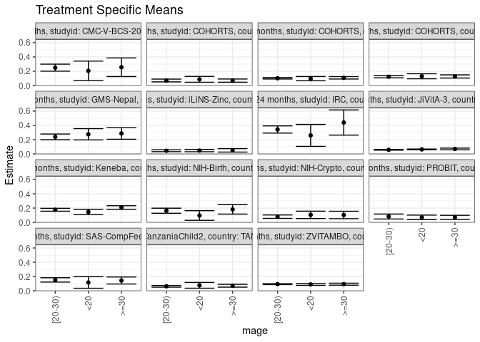

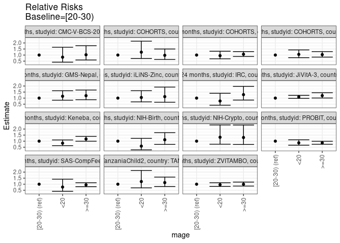

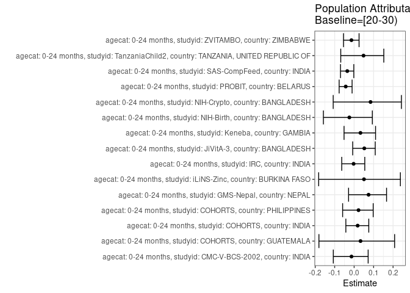

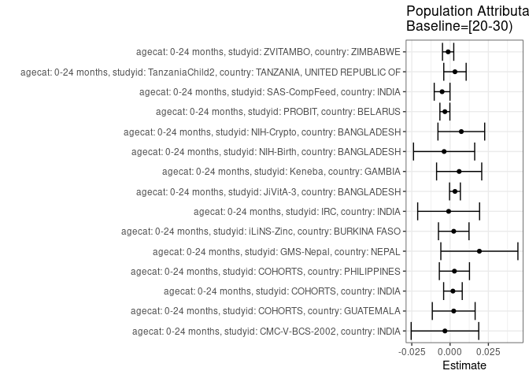

## Results Table

### Parameter: TSM

| agecat | studyid | country | intervention_level | baseline_level | estimate | ci_lower | ci_upper |
| --- | --- | --- | --- | --- | --- | --- | --- |
| 0-24 months | CMC-V-BCS-2002 | INDIA | [20-30) | NA | 0.2500000 | 0.2006047 | 0.2993953 |
| 0-24 months | CMC-V-BCS-2002 | INDIA | <20 | NA | 0.2058824 | 0.0697869 | 0.3419778 |
| 0-24 months | CMC-V-BCS-2002 | INDIA | >=30 | NA | 0.2558140 | 0.1252270 | 0.3864009 |
| 0-24 months | COHORTS | GUATEMALA | [20-30) | NA | 0.0699588 | 0.0505594 | 0.0893582 |
| 0-24 months | COHORTS | GUATEMALA | <20 | NA | 0.0866365 | 0.0455623 | 0.1277107 |
| 0-24 months | COHORTS | GUATEMALA | >=30 | NA | 0.0683632 | 0.0459893 | 0.0907372 |
| 0-24 months | COHORTS | INDIA | [20-30) | NA | 0.1012496 | 0.0911919 | 0.1113073 |
| 0-24 months | COHORTS | INDIA | <20 | NA | 0.0960988 | 0.0662483 | 0.1259492 |
| 0-24 months | COHORTS | INDIA | >=30 | NA | 0.1078675 | 0.0908060 | 0.1249291 |
| 0-24 months | COHORTS | PHILIPPINES | [20-30) | NA | 0.1226267 | 0.1074102 | 0.1378431 |
| 0-24 months | COHORTS | PHILIPPINES | <20 | NA | 0.1293605 | 0.0940737 | 0.1646474 |
| 0-24 months | COHORTS | PHILIPPINES | >=30 | NA | 0.1267833 | 0.1044727 | 0.1490938 |
| 0-24 months | GMS-Nepal | NEPAL | [20-30) | NA | 0.2388965 | 0.1987858 | 0.2790072 |
| 0-24 months | GMS-Nepal | NEPAL | <20 | NA | 0.2753997 | 0.1963484 | 0.3544510 |
| 0-24 months | GMS-Nepal | NEPAL | >=30 | NA | 0.2867431 | 0.2059557 | 0.3675305 |
| 0-24 months | iLiNS-Zinc | BURKINA FASO | [20-30) | NA | 0.0447965 | 0.0315461 | 0.0580469 |
| 0-24 months | iLiNS-Zinc | BURKINA FASO | <20 | NA | 0.0470574 | 0.0307556 | 0.0633593 |
| 0-24 months | iLiNS-Zinc | BURKINA FASO | >=30 | NA | 0.0501769 | 0.0261329 | 0.0742209 |
| 0-24 months | IRC | INDIA | [20-30) | NA | 0.3424109 | 0.2921059 | 0.3927160 |
| 0-24 months | IRC | INDIA | <20 | NA | 0.2596304 | 0.1055903 | 0.4136705 |
| 0-24 months | IRC | INDIA | >=30 | NA | 0.4401179 | 0.2638764 | 0.6163595 |
| 0-24 months | JiVitA-3 | BANGLADESH | [20-30) | NA | 0.0578252 | 0.0529467 | 0.0627037 |
| 0-24 months | JiVitA-3 | BANGLADESH | <20 | NA | 0.0633329 | 0.0578902 | 0.0687756 |
| 0-24 months | JiVitA-3 | BANGLADESH | >=30 | NA | 0.0696488 | 0.0580788 | 0.0812188 |
| 0-24 months | Keneba | GAMBIA | [20-30) | NA | 0.1763396 | 0.1560664 | 0.1966127 |
| 0-24 months | Keneba | GAMBIA | <20 | NA | 0.1462392 | 0.1088285 | 0.1836499 |
| 0-24 months | Keneba | GAMBIA | >=30 | NA | 0.2076519 | 0.1823143 | 0.2329896 |
| 0-24 months | NIH-Birth | BANGLADESH | [20-30) | NA | 0.1630695 | 0.1275833 | 0.1985558 |
| 0-24 months | NIH-Birth | BANGLADESH | <20 | NA | 0.0958904 | 0.0282924 | 0.1634885 |
| 0-24 months | NIH-Birth | BANGLADESH | >=30 | NA | 0.1818182 | 0.1159684 | 0.2476679 |
| 0-24 months | NIH-Crypto | BANGLADESH | [20-30) | NA | 0.0797363 | 0.0558815 | 0.1035911 |
| 0-24 months | NIH-Crypto | BANGLADESH | <20 | NA | 0.1053564 | 0.0541376 | 0.1565752 |
| 0-24 months | NIH-Crypto | BANGLADESH | >=30 | NA | 0.1037557 | 0.0517731 | 0.1557384 |
| 0-24 months | PROBIT | BELARUS | [20-30) | NA | 0.0818008 | 0.0470506 | 0.1165511 |
| 0-24 months | PROBIT | BELARUS | <20 | NA | 0.0703743 | 0.0389002 | 0.1018484 |
| 0-24 months | PROBIT | BELARUS | >=30 | NA | 0.0701372 | 0.0410276 | 0.0992468 |
| 0-24 months | SAS-CompFeed | INDIA | [20-30) | NA | 0.1525924 | 0.1221680 | 0.1830168 |
| 0-24 months | SAS-CompFeed | INDIA | <20 | NA | 0.1164718 | 0.0357384 | 0.1972052 |
| 0-24 months | SAS-CompFeed | INDIA | >=30 | NA | 0.1438637 | 0.0946592 | 0.1930682 |
| 0-24 months | TanzaniaChild2 | TANZANIA, UNITED REPUBLIC OF | [20-30) | NA | 0.0628919 | 0.0508661 | 0.0749177 |
| 0-24 months | TanzaniaChild2 | TANZANIA, UNITED REPUBLIC OF | <20 | NA | 0.0766271 | 0.0362231 | 0.1170311 |
| 0-24 months | TanzaniaChild2 | TANZANIA, UNITED REPUBLIC OF | >=30 | NA | 0.0711400 | 0.0511939 | 0.0910861 |
| 0-24 months | ZVITAMBO | ZIMBABWE | [20-30) | NA | 0.0932366 | 0.0871115 | 0.0993617 |
| 0-24 months | ZVITAMBO | ZIMBABWE | <20 | NA | 0.0890983 | 0.0763308 | 0.1018659 |
| 0-24 months | ZVITAMBO | ZIMBABWE | >=30 | NA | 0.0929190 | 0.0789491 | 0.1068889 |

### Parameter: E(Y)

| agecat | studyid | country | intervention_level | baseline_level | estimate | ci_lower | ci_upper |
| --- | --- | --- | --- | --- | --- | --- | --- |
| 0-24 months | CMC-V-BCS-2002 | INDIA | NA | NA | 0.2466488 | 0.2028447 | 0.2904529 |
| 0-24 months | COHORTS | GUATEMALA | NA | NA | 0.0723341 | 0.0584645 | 0.0862036 |
| 0-24 months | COHORTS | INDIA | NA | NA | 0.1031103 | 0.0949263 | 0.1112943 |
| 0-24 months | COHORTS | PHILIPPINES | NA | NA | 0.1254516 | 0.1136848 | 0.1372183 |
| 0-24 months | GMS-Nepal | NEPAL | NA | NA | 0.2580175 | 0.2252514 | 0.2907836 |
| 0-24 months | iLiNS-Zinc | BURKINA FASO | NA | NA | 0.0471846 | 0.0353428 | 0.0590265 |
| 0-24 months | IRC | INDIA | NA | NA | 0.3414634 | 0.2955068 | 0.3874201 |
| 0-24 months | JiVitA-3 | BANGLADESH | NA | NA | 0.0610132 | 0.0575333 | 0.0644930 |
| 0-24 months | Keneba | GAMBIA | NA | NA | 0.1822626 | 0.1681211 | 0.1964040 |
| 0-24 months | NIH-Birth | BANGLADESH | NA | NA | 0.1591640 | 0.1303913 | 0.1879367 |
| 0-24 months | NIH-Crypto | BANGLADESH | NA | NA | 0.0870712 | 0.0669870 | 0.1071555 |
| 0-24 months | PROBIT | BELARUS | NA | NA | 0.0784116 | 0.0458146 | 0.1110087 |
| 0-24 months | SAS-CompFeed | INDIA | NA | NA | 0.1473893 | 0.1184132 | 0.1763654 |
| 0-24 months | TanzaniaChild2 | TANZANIA, UNITED REPUBLIC OF | NA | NA | 0.0660774 | 0.0560867 | 0.0760682 |
| 0-24 months | ZVITAMBO | ZIMBABWE | NA | NA | 0.0919615 | 0.0871588 | 0.0967642 |

### Parameter: RR

| agecat | studyid | country | intervention_level | baseline_level | estimate | ci_lower | ci_upper |
| --- | --- | --- | --- | --- | --- | --- | --- |
| 0-24 months | CMC-V-BCS-2002 | INDIA | [20-30) | [20-30) | 1.0000000 | 1.0000000 | 1.0000000 |
| 0-24 months | CMC-V-BCS-2002 | INDIA | <20 | [20-30) | 0.8235294 | 0.4130909 | 1.6417711 |
| 0-24 months | CMC-V-BCS-2002 | INDIA | >=30 | [20-30) | 1.0232558 | 0.5919164 | 1.7689196 |
| 0-24 months | COHORTS | GUATEMALA | [20-30) | [20-30) | 1.0000000 | 1.0000000 | 1.0000000 |
| 0-24 months | COHORTS | GUATEMALA | <20 | [20-30) | 1.2383928 | 0.7149814 | 2.1449744 |
| 0-24 months | COHORTS | GUATEMALA | >=30 | [20-30) | 0.9771926 | 0.6361537 | 1.5010607 |
| 0-24 months | COHORTS | INDIA | [20-30) | [20-30) | 1.0000000 | 1.0000000 | 1.0000000 |
| 0-24 months | COHORTS | INDIA | <20 | [20-30) | 0.9491276 | 0.6851453 | 1.3148206 |
| 0-24 months | COHORTS | INDIA | >=30 | [20-30) | 1.0653626 | 0.8841849 | 1.2836653 |
| 0-24 months | COHORTS | PHILIPPINES | [20-30) | [20-30) | 1.0000000 | 1.0000000 | 1.0000000 |
| 0-24 months | COHORTS | PHILIPPINES | <20 | [20-30) | 1.0549136 | 0.7818227 | 1.4233952 |
| 0-24 months | COHORTS | PHILIPPINES | >=30 | [20-30) | 1.0338966 | 0.8335689 | 1.2823680 |
| 0-24 months | GMS-Nepal | NEPAL | [20-30) | [20-30) | 1.0000000 | 1.0000000 | 1.0000000 |
| 0-24 months | GMS-Nepal | NEPAL | <20 | [20-30) | 1.1527990 | 0.8266520 | 1.6076240 |
| 0-24 months | GMS-Nepal | NEPAL | >=30 | [20-30) | 1.2002814 | 0.8647560 | 1.6659907 |
| 0-24 months | iLiNS-Zinc | BURKINA FASO | [20-30) | [20-30) | 1.0000000 | 1.0000000 | 1.0000000 |
| 0-24 months | iLiNS-Zinc | BURKINA FASO | <20 | [20-30) | 1.0504715 | 0.6842011 | 1.6128160 |
| 0-24 months | iLiNS-Zinc | BURKINA FASO | >=30 | [20-30) | 1.1201072 | 0.6571601 | 1.9091847 |
| 0-24 months | IRC | INDIA | [20-30) | [20-30) | 1.0000000 | 1.0000000 | 1.0000000 |
| 0-24 months | IRC | INDIA | <20 | [20-30) | 0.7582422 | 0.4114194 | 1.3974334 |
| 0-24 months | IRC | INDIA | >=30 | [20-30) | 1.2853501 | 0.8390548 | 1.9690309 |
| 0-24 months | JiVitA-3 | BANGLADESH | [20-30) | [20-30) | 1.0000000 | 1.0000000 | 1.0000000 |
| 0-24 months | JiVitA-3 | BANGLADESH | <20 | [20-30) | 1.0952480 | 0.9779957 | 1.2265578 |
| 0-24 months | JiVitA-3 | BANGLADESH | >=30 | [20-30) | 1.2044725 | 1.0076664 | 1.4397165 |
| 0-24 months | Keneba | GAMBIA | [20-30) | [20-30) | 1.0000000 | 1.0000000 | 1.0000000 |
| 0-24 months | Keneba | GAMBIA | <20 | [20-30) | 0.8293044 | 0.6266401 | 1.0975131 |
| 0-24 months | Keneba | GAMBIA | >=30 | [20-30) | 1.1775684 | 0.9958326 | 1.3924703 |
| 0-24 months | NIH-Birth | BANGLADESH | [20-30) | [20-30) | 1.0000000 | 1.0000000 | 1.0000000 |
| 0-24 months | NIH-Birth | BANGLADESH | <20 | [20-30) | 0.5880338 | 0.2811840 | 1.2297419 |
| 0-24 months | NIH-Birth | BANGLADESH | >=30 | [20-30) | 1.1149733 | 0.7307436 | 1.7012334 |
| 0-24 months | NIH-Crypto | BANGLADESH | [20-30) | [20-30) | 1.0000000 | 1.0000000 | 1.0000000 |
| 0-24 months | NIH-Crypto | BANGLADESH | <20 | [20-30) | 1.3213113 | 0.7470520 | 2.3370040 |
| 0-24 months | NIH-Crypto | BANGLADESH | >=30 | [20-30) | 1.3012366 | 0.7257390 | 2.3330930 |
| 0-24 months | PROBIT | BELARUS | [20-30) | [20-30) | 1.0000000 | 1.0000000 | 1.0000000 |
| 0-24 months | PROBIT | BELARUS | <20 | [20-30) | 0.8603130 | 0.6678335 | 1.1082681 |
| 0-24 months | PROBIT | BELARUS | >=30 | [20-30) | 0.8574148 | 0.7422879 | 0.9903975 |
| 0-24 months | SAS-CompFeed | INDIA | [20-30) | [20-30) | 1.0000000 | 1.0000000 | 1.0000000 |
| 0-24 months | SAS-CompFeed | INDIA | <20 | [20-30) | 0.7632870 | 0.4126184 | 1.4119754 |
| 0-24 months | SAS-CompFeed | INDIA | >=30 | [20-30) | 0.9427973 | 0.7946437 | 1.1185727 |
| 0-24 months | TanzaniaChild2 | TANZANIA, UNITED REPUBLIC OF | [20-30) | [20-30) | 1.0000000 | 1.0000000 | 1.0000000 |
| 0-24 months | TanzaniaChild2 | TANZANIA, UNITED REPUBLIC OF | <20 | [20-30) | 1.2183935 | 0.6953490 | 2.1348744 |
| 0-24 months | TanzaniaChild2 | TANZANIA, UNITED REPUBLIC OF | >=30 | [20-30) | 1.1311478 | 0.8055722 | 1.5883063 |
| 0-24 months | ZVITAMBO | ZIMBABWE | [20-30) | [20-30) | 1.0000000 | 1.0000000 | 1.0000000 |
| 0-24 months | ZVITAMBO | ZIMBABWE | <20 | [20-30) | 0.9556153 | 0.8162650 | 1.1187552 |
| 0-24 months | ZVITAMBO | ZIMBABWE | >=30 | [20-30) | 0.9965933 | 0.8457778 | 1.1743017 |

### Parameter: PAR

| agecat | studyid | country | intervention_level | baseline_level | estimate | ci_lower | ci_upper |
| --- | --- | --- | --- | --- | --- | --- | --- |
| 0-24 months | CMC-V-BCS-2002 | INDIA | [20-30) | NA | -0.0033512 | -0.0254025 | 0.0187001 |
| 0-24 months | COHORTS | GUATEMALA | [20-30) | NA | 0.0023753 | -0.0116021 | 0.0163526 |
| 0-24 months | COHORTS | INDIA | [20-30) | NA | 0.0018607 | -0.0042102 | 0.0079316 |
| 0-24 months | COHORTS | PHILIPPINES | [20-30) | NA | 0.0028249 | -0.0070103 | 0.0126601 |
| 0-24 months | GMS-Nepal | NEPAL | [20-30) | NA | 0.0191210 | -0.0060323 | 0.0442742 |
| 0-24 months | iLiNS-Zinc | BURKINA FASO | [20-30) | NA | 0.0023882 | -0.0075819 | 0.0123582 |
| 0-24 months | IRC | INDIA | [20-30) | NA | -0.0009475 | -0.0211485 | 0.0192535 |
| 0-24 months | JiVitA-3 | BANGLADESH | [20-30) | NA | 0.0031880 | -0.0003429 | 0.0067189 |
| 0-24 months | Keneba | GAMBIA | [20-30) | NA | 0.0059230 | -0.0088111 | 0.0206571 |
| 0-24 months | NIH-Birth | BANGLADESH | [20-30) | NA | -0.0039056 | -0.0238720 | 0.0160609 |
| 0-24 months | NIH-Crypto | BANGLADESH | [20-30) | NA | 0.0073350 | -0.0079197 | 0.0225896 |
| 0-24 months | PROBIT | BELARUS | [20-30) | NA | -0.0033892 | -0.0066477 | -0.0001307 |
| 0-24 months | SAS-CompFeed | INDIA | [20-30) | NA | -0.0052031 | -0.0103458 | -0.0000604 |
| 0-24 months | TanzaniaChild2 | TANZANIA, UNITED REPUBLIC OF | [20-30) | NA | 0.0031855 | -0.0041167 | 0.0104878 |
| 0-24 months | ZVITAMBO | ZIMBABWE | [20-30) | NA | -0.0012751 | -0.0049512 | 0.0024009 |

### Parameter: PAF

| agecat | studyid | country | intervention_level | baseline_level | estimate | ci_lower | ci_upper |
| --- | --- | --- | --- | --- | --- | --- | --- |
| 0-24 months | CMC-V-BCS-2002 | INDIA | [20-30) | NA | -0.0135870 | -0.1070401 | 0.0719771 |
| 0-24 months | COHORTS | GUATEMALA | [20-30) | NA | 0.0328374 | -0.1809508 | 0.2079234 |
| 0-24 months | COHORTS | INDIA | [20-30) | NA | 0.0180454 | -0.0426108 | 0.0751729 |
| 0-24 months | COHORTS | PHILIPPINES | [20-30) | NA | 0.0225178 | -0.0591053 | 0.0978503 |
| 0-24 months | GMS-Nepal | NEPAL | [20-30) | NA | 0.0741072 | -0.0285830 | 0.1665452 |
| 0-24 months | iLiNS-Zinc | BURKINA FASO | [20-30) | NA | 0.0506129 | -0.1821962 | 0.2375751 |
| 0-24 months | IRC | INDIA | [20-30) | NA | -0.0027749 | -0.0637139 | 0.0546729 |
| 0-24 months | JiVitA-3 | BANGLADESH | [20-30) | NA | 0.0522511 | -0.0074055 | 0.1083749 |
| 0-24 months | Keneba | GAMBIA | [20-30) | NA | 0.0324970 | -0.0518192 | 0.1100543 |
| 0-24 months | NIH-Birth | BANGLADESH | [20-30) | NA | -0.0245379 | -0.1579328 | 0.0934897 |
| 0-24 months | NIH-Crypto | BANGLADESH | [20-30) | NA | 0.0842411 | -0.1075649 | 0.2428305 |
| 0-24 months | PROBIT | BELARUS | [20-30) | NA | -0.0432229 | -0.0769999 | -0.0105052 |
| 0-24 months | SAS-CompFeed | INDIA | [20-30) | NA | -0.0353018 | -0.0700598 | -0.0016727 |
| 0-24 months | TanzaniaChild2 | TANZANIA, UNITED REPUBLIC OF | [20-30) | NA | 0.0482091 | -0.0687643 | 0.1523800 |
| 0-24 months | ZVITAMBO | ZIMBABWE | [20-30) | NA | -0.0138661 | -0.0546255 | 0.0253180 |